# Microsimulation - Household Carbon Tax in Argentina

Author

Priscilla Stitsman, Ines Dezcallar, David Gentili and Asad Azhar

# Microsimulation Model Proposal: Household-Level Carbon Tax in Argentina

## Objective

To evaluate the distributional impact and policy design trade-offs of implementing a household-level carbon tax in Argentina, using a microsimulation model based on household energy expenditure data and carbon pricing structures from Argentina and added policies from developed countries.

## Policy Context

### Rationale for Carbon Pricing

- Carbon taxes are a cost-effective means of reducing emissions compared to command-and-control regulations or subsidies (Gugler et al., 2021).
- As a Pigouvian tax, carbon pricing helps internalize the external costs of carbon emissions, creating incentives for households to adjust their energy consumption behavior toward cleaner alternatives.

### Current Carbon Tax Landscape in Argentina

- Since 2017, Argentina has implemented a carbon tax (Ley N° 23.966), but:
  - It applies upstream (to fuel importers and producers) and not directly to households.
  - The tax structure is based on fixed amounts adjusted for inflation, currently equivalent to ~$10/tCO2E.
  - Tax rates are lower than Canada (~$50/tCO2E), though higher than regional peers (Chile, Colombia, Mexico).
  - Multiple exemptions and policy shifts have weakened the intended impact (e.g., diesel and gasoil exemptions in 2018 and 2020).

### Lessons from Canada

- Canada applies a higher and more uniform carbon price (~$50/tCO2E).
- Provides direct lump-sum rebates to households based on family size, rural location, and province.
- This model serves as a benchmark for balancing equity and efficiency in policy design.

## Microsimulation Model Structure

- Use microdata from Argentina’s national household expenditure survey (e.g., EPH, ENGHo) to estimate baseline household spending on energy sources
- Apply carbon price increases to each energy source using the official carbon content conversion table (from Argentina’s tax authority or IPCC guidelines).
- Start with Argentina’s current rates, and escalate to $50/tCO2E to simulate the Canadian-equivalent carbon price.
- Model price pass-through to consumers under the assumption that households ultimately bear the tax burden through higher energy prices.

### Heterogeneous Price Scenarios

- Simulate different carbon price levels (e.g., $10, $25, $50/tCO2E) to compare distributional effects under:
  - A uniform price across all households.
  - A differential price structure based on income quintiles (e.g., lower rates for the poor).

### Distributional Analysis

- Estimate post-tax energy expenditures for each household
- Estimate impact on income and income distribution
- Estimate impact per income quintiles
- Evaluate revenue recycling mechanisms through cash transfers:
  - Flat per capita rebate (uniform transfer to all)
  - Progressive rebate (Enhanced rebates for lower-income households, Higher transfers for rural areas (aligned with Canadian policy))
  - Compare net distributional impacts: tax paid minus rebate received.

## Data processing

Uploading necessary packages

```r
library(readr)
library(here)
library(tidyverse)
```

```r
#####  Household - WE USE THIS FOR HOUSEHOLD INCOME
hh_2018 <- read_delim(here("data","engho2018_hogares.txt"),
  delim = "|",
  col_names = FALSE,
  locale = locale(encoding = "Latin1")
)

colnames(hh_2018) <- strsplit(
  "id.provincia.region.subregion.trimestre.anio.pondera.cv1c04.cv1c05_a.cv1c05_b.cv1c05_c.cv1c05_d.cv1c06_e.cv1c06_f.cv1c07.cv1c08.cv1c09.cv1c10.cv1c11.cv1c12.cv1c13.ch01.ch02.ch03.ch04.ch05.ch06.ch07.ch08.ch09.ch10.ch11.ch12.ch13.ch14.ch15.ch16.ch17_a.ch17_b.ch18.ch19.ch20.ch21.propauto.regten.hacina.jniveled.jsexo.jedad_agrup.jsitconyugal.jdif_lp.jestado.jocupengh.jpercept.jcomed.tipohog.cantping.reldep.cantmiem.cantadequi.menor18.menor14.mayor65.dif_lph.cant_act.permieoc.clima_educativo.gastot.gastotpc.gasto_comunh.gascomp.gasvent.gc_01.gc_02.gc_03.gc_04.gc_05.gc_06.gc_07.gc_08.gc_09.gc_10.gc_11.gc_12.gc09_01.gc09_02.gc09_03.gc09_04.gc09_05.gc09_06.gc09_07.gc09_08.gc09_09.fp_contado.fp_credito.fp_especie.fp_prodprop.fp_tarjetas.fp_otras.fp_indef.tn_hipsup.tn_autoserv.tn_negesp.tn_restaurant.tn_kiosco.tn_internet.tn_comedor.tn_especie.tn_otros.tn_indef.decgaphp.decgaphr.decgapht.quigaphp.quigaphr.quigapht.gasto_imputado.m_gasto_imputado.ingtoth.ingpch.m_ingtoth.ingtoth_imp.qinth_p.qinth_r.qinth_t.dinth_p.dinth_r.dinth_t.qinpch_p.qinpch_r.qinpch_t.dinpch_p.dinpch_r.dinpch_t",
  "\\."
)[[1]]

# Count of missing values in each column
colSums(is.na(hh_2018))
```

```
              id        provincia           region        subregion
               0                0                0                0
       trimestre             anio          pondera           cv1c04
               0                0                0                0
        cv1c05_a         cv1c05_b         cv1c05_c         cv1c05_d
             348              348              348              348
        cv1c06_e         cv1c06_f           cv1c07           cv1c08
               0                0                0                0
          cv1c09           cv1c10           cv1c11           cv1c12
               0                0                0                0
          cv1c13             ch01             ch02             ch03
               0                0             6477             6477
            ch04             ch05             ch06             ch07
            6477                0                0                0
            ch08             ch09             ch10             ch11
               0                0                0              122
            ch12             ch13             ch14             ch15
             122              541              122                0
            ch16           ch17_a           ch17_b             ch18
               0                0                0             1334
            ch19             ch20             ch21         propauto
               0                0                0                0
          regten           hacina         jniveled            jsexo
               0                0                0                0
     jedad_agrup     jsitconyugal          jdif_lp          jestado
               0                0                0                0
       jocupengh         jpercept           jcomed          tipohog
            7591                0                0                0
        cantping           reldep         cantmiem       cantadequi
               0               17                0                0
         menor18          menor14          mayor65          dif_lph
               0                0                0                0
        cant_act         permieoc  clima_educativo           gastot
               0             4313                0                0
        gastotpc     gasto_comunh          gascomp          gasvent
               0                0                0                0
           gc_01            gc_02            gc_03            gc_04
               0                0                0                0
           gc_05            gc_06            gc_07            gc_08
               0                0                0                0
```

[output cut: 13 more lines]

```
               0                0                0                0
        tn_otros         tn_indef         decgaphp         decgaphr
               0                0                0                0
        decgapht         quigaphp         quigaphr         quigapht
               0                0                0                0
  gasto_imputado m_gasto_imputado          ingtoth           ingpch
               0                0                0                0
       m_ingtoth      ingtoth_imp          qinth_p          qinth_r
               0                0                0                0
         qinth_t          dinth_p          dinth_r          dinth_t
               0                0                0                0
        qinpch_p         qinpch_r         qinpch_t         dinpch_p
               0                0                0                0
        dinpch_r         dinpch_t
               0                0
```

```r
# First rows as colnames
colnames(hh_2018) <- as.character(unlist(hh_2018[1, ]))
hh_2018 <- hh_2018[-1, ]
hh_2018 <- type.convert(hh_2018, as.is = TRUE)

##### Expenditures - WE USE THIS FOR HOUSEHOLD EXPENDITURE IN ENERGY

gastos <- read_delim((here("data",
                           "engho2018_gastos.txt")),
                     delim = "|",
                     locale = locale(encoding = "Latin1"))
##### Codebook

codes <- read_delim(here("data",
  "engho2018_articulos.txt"),
  delim = "|",
  locale = locale(encoding = "Latin1")
)
```

```r
########################################################
##### Energy expenditure: electricity, gas, others #####
########################################################


energy_exp <- gastos %>%
  filter(articulo %in% c("A0451101", "A0451102", "A0451103",
                         "A0452101", "A0452102", "A0452103",
                         "A0452104", "A0452105",
                         "A0453101", "A0453102", "A0453103")) %>%
  mutate(articulo_label = case_when(
    articulo == "A0451101" ~ "Electricidad - vivienda principal",
    articulo == "A0451102" ~ "Electricidad - vivienda secundaria",
    articulo == "A0451103" ~ "Gastos de electricidad realizados para una vivienda ocupada por otro hogar",
    articulo == "A0452101" ~ "Gas envasado en garrafas",
    articulo == "A0452102" ~ "Gas a granel",
    articulo == "A0452103" ~ "Gas natural - vivienda principal",
    articulo == "A0452104" ~ "Gas envasado en tubo",
    articulo == "A0452105" ~ "Gas natural - vivienda secundaria",
    articulo == "A0453101" ~ "Kerosene",
    articulo == "A0453102" ~ "Leña y carbón",
    articulo == "A0453103" ~ "Otros combustibles para el hogar",
    TRUE ~ "Otro"
  ))


###########################
##### Household Income ####
###########################

income_hh <- hh_2018 %>% select(id, ingtoth, ingpch)


## Join

carbon_tax <- energy_exp %>%
  left_join(income_hh %>% select(id, ingtoth), by = "id") %>%
  select (-miembro, -subclase, -clase, -grupo, -division, -forma_pago, -modo_adq, -lugar_adq, -tipo_negocio)
```

## Exploratory Analysis

```r
#Compute total energy spend & share of income per household
df_house <- carbon_tax %>%
  group_by(id, ingtoth) %>%
  summarize(
    total_energy = sum(monto),
    .groups = "drop"
  ) %>%
  mutate(
    energy_share = total_energy / ingtoth
  )

#Bring quintiles of income back in
df_house <- df_house %>%
  mutate(
    income_quintile = ntile(ingtoth, 5)
  )

#Merge article-level data back on, in case you need detailed per-fuel stats
df_detail <- carbon_tax %>%
  left_join(
    select(df_house, id, energy_share, income_quintile),
    by = "id"
  )

#We need to check the values where people spend over 100% of their income in energy
df_house <- df_house %>%
  filter(energy_share < 1)
```

### Distribution of energy expenditure as a share of income

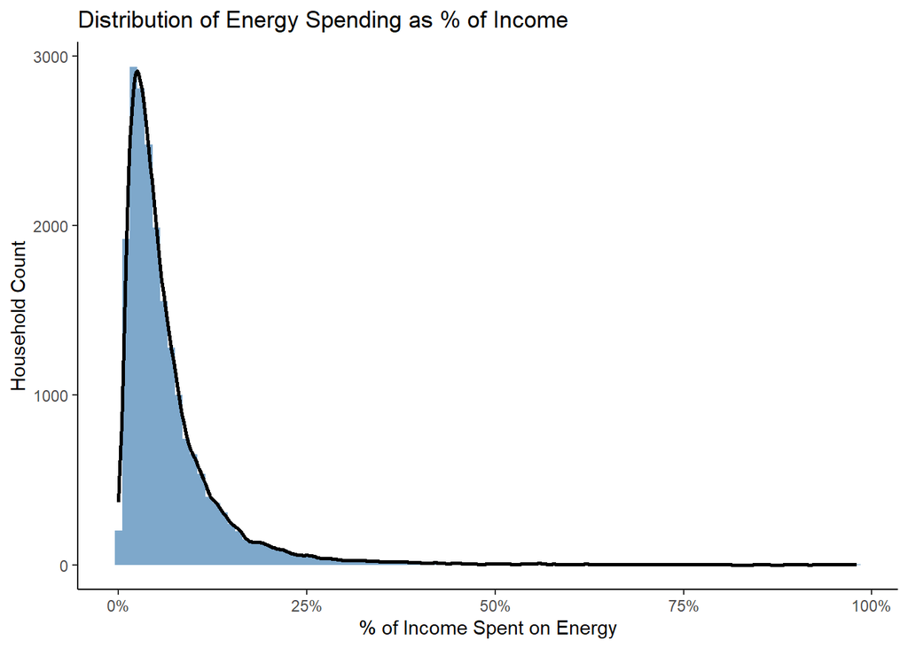

```r
ggplot(df_house, aes(x = energy_share)) +
  geom_histogram(binwidth = 0.01, fill = "steelblue", alpha = 0.7) +
  geom_density(aes(y = ..count..*0.01), color = "black", size = 1) +
  scale_x_continuous(labels = scales::percent) +
  labs(
    x = "% of Income Spent on Energy",
    y = "Household Count",
    title = "Distribution of Energy Spending as % of Income"
  ) +
  theme_classic()
```

### Distribution of energy expenditure as a share of income by quintiles

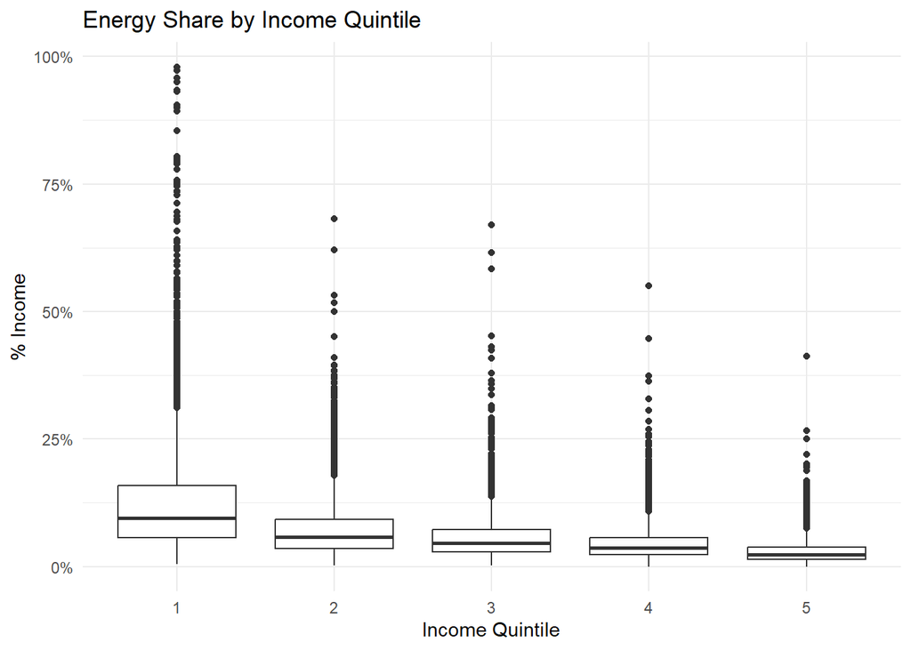

```r
ggplot(df_house, aes(factor(income_quintile), energy_share)) +
  geom_boxplot() +
  scale_y_continuous(labels = scales::percent) +
  labs(
    x = "Income Quintile",
    y = "% Income",
    title = "Energy Share by Income Quintile"
  ) +
  theme_minimal()
```

### Income distribution

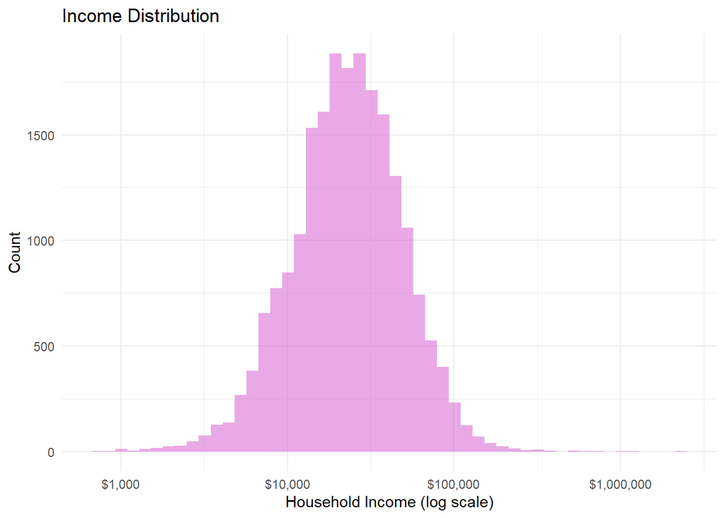

```r
ggplot(df_house, aes(x = ingtoth)) +
  geom_histogram(bins = 50, fill = "orchid", alpha = 0.6) +
  scale_x_log10(labels = scales::dollar) +
  labs(
    x = "Household Income (log scale)",
    y = "Count",
    title = "Income Distribution"
  ) +
  theme_minimal()
```

### Income spent by energy type x income quintile (Bar chart)

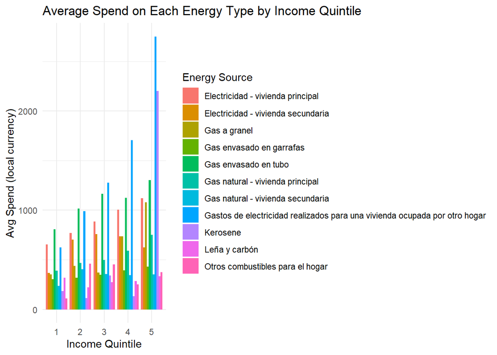

```r
fuel_quint <- df_detail %>%
  group_by(income_quintile, articulo_label) %>%
  summarize(
    mean_spend = mean(monto),
    .groups = "drop"
  )

ggplot(fuel_quint, aes(
  x = factor(income_quintile),
  y = mean_spend,
  fill = articulo_label
)) +
  geom_col(position = "dodge") +
  labs(
    x = "Income Quintile",
    y = "Avg Spend (local currency)",
    fill = "Energy Source",
    title = "Average Spend on Each Energy Type by Income Quintile"
  ) +
  theme_minimal()
```

### Income spent by energy type x income quintile (Facet)

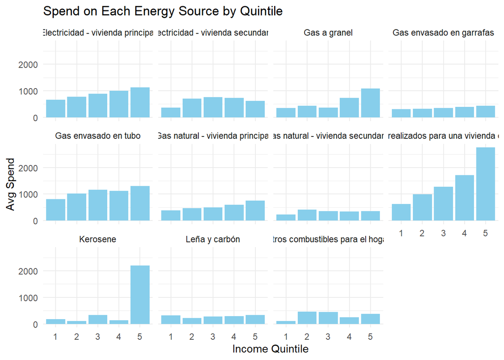

```r
ggplot(fuel_quint, aes(x = factor(income_quintile), y = mean_spend)) +
  geom_col(fill = "skyblue") +
  facet_wrap(~ articulo_label) +
  labs(
    x = "Income Quintile",
    y = "Avg Spend",
    title = "Spend on Each Energy Source by Quintile"
  ) +
  theme_minimal()
```

### Total spent on each energy source

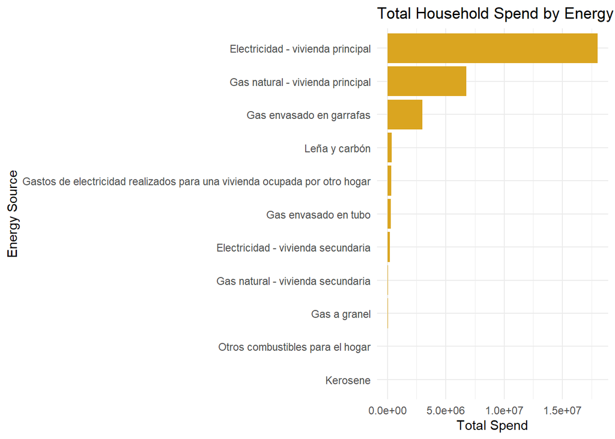

```r
totals <- carbon_tax %>%
  group_by(articulo_label) %>%
  summarize(total_spend = sum(monto), .groups = "drop")

ggplot(totals, aes(x = reorder(articulo_label, total_spend), y = total_spend)) +
  geom_col(fill = "goldenrod") +
  coord_flip() +
  labs(
    x = "Energy Source",
    y = "Total Spend",
    title = "Total Household Spend by Energy Source"
  ) +
  theme_minimal()
```